# Scratch: Turtle Command Strings (directions for `Scratch: L-sys Turtle pic 3`)

Wouldn’t it be great if we didn’t have to type the turtle commands one keystroke at a time? Well, I’ve got some great news; today we will update our Scratch code so we can simply paste a long string of commands into an `ask/answer` text box.

1. **Save your turtle project AS A COPY**. You could name the copy “Turbo Turtle”.
2. Make variables.

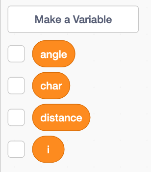

3. Make lists. You probably already have these lists.

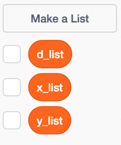

4. Alter your code. You’ll notice that a lot of the code from your last project is repeated here. It’ll be faster to rearrange your old code than rewrite the whole thing.

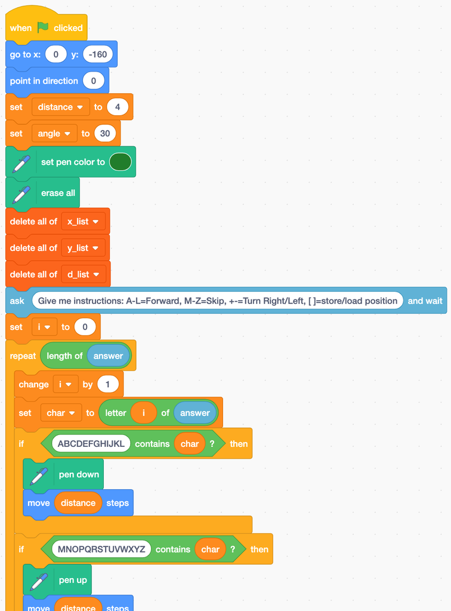

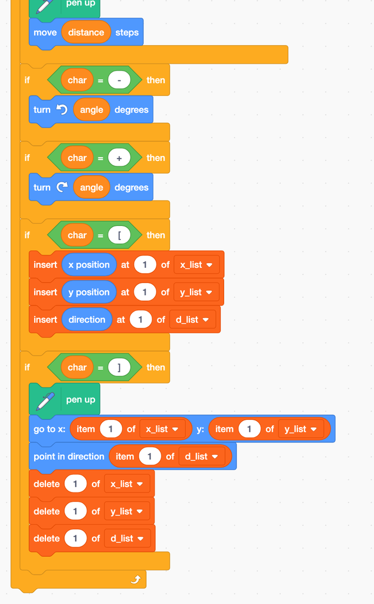

5. Go to this L-system string generator: https://chadworley.github.io/Lsys_string_gen.html
6. Use the following settings:

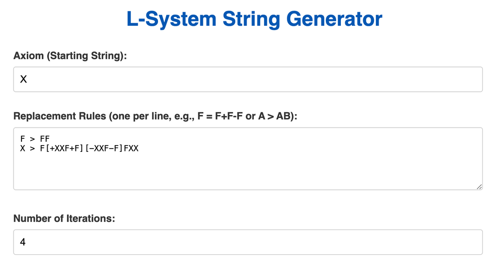

7. Click `Generate Strings`.
8. Click `Copy Last String`.
9. Edit the Scratch parameters. We want to start at $(0,-160)$ heading up, have the distance of each step be $4$, and the turn angle is 30°. I also think the drawing will look good in green, but you can use any color.

[figure not shown]

10. In Scratch, click the green flag. Paste the string into the popup. Hit ENTER. You might find Turbo mode helpful.
11. Take a screenshot of the resulting image (including your turtle). Submit your image on Canvas under assignment `Scratch: L-sys Turtle (pic 3)`.